# Flight Data Analysis: NYC Departures in 2013

Dogan the Analyst

2025-01-13

```r
library(tidyverse)
library(nycflights13)
```

## Project Description

The purpose of this project is to explore and explain observations in the `flights` data set by transforming and visualizing the data.

### In this task I want create a data set that lists the days during 2013 on which the percentage of flights that were either canceled or delayed on departure by more than one hour exceeded 35%.

```r
days_exceed_35 <- flights %>%
  filter(year == 2013) %>%
  group_by(month, day) %>%
  summarize(
    total_flights = n(),
    canceled_or_delayed = sum(is.na(dep_delay) | dep_delay > 60),
    exceed_35 = (canceled_or_delayed / total_flights) * 100
  ) %>%
  filter(exceed_35 > 35)

days_exceed_35
```

```
## # A tibble: 12 × 5
## # Groups:   month [7]
##    month   day total_flights canceled_or_delayed exceed_35
##    <int> <int>         <int>               <int>     <dbl>
##  1     2     8           930                 506      54.4
##  2     2     9           684                 419      61.3
##  3     3     8           979                 574      58.6
##  4     5    23           988                 435      44.0
##  5     6    24           994                 348      35.0
##  6     6    28           994                 369      37.1
##  7     7     1           966                 407      42.1
##  8     7    10          1004                 364      36.3
##  9     7    23           997                 362      36.3
## 10     9     2           929                 326      35.1
## 11     9    12           992                 404      40.7
## 12    12     5           969                 385      39.7
```

### I also created a data set that shows, for each scheduled departure hour during the day, the percentage of flights that were canceled or delayed by more than one hour.

```r
per_cancel_or_delayed_by_hour <- flights %>%
  group_by(sched_dep_time) %>%
  summarize(
    total_flights = n(),
    can_or_del = sum(is.na(dep_delay) | dep_delay > 60),
    percentage_can_or_del = (can_or_del / total_flights) * 100
  )

per_cancel_or_delayed_by_hour
```

```
## # A tibble: 1,021 × 4
##    sched_dep_time total_flights can_or_del percentage_can_or_del
##             <int>         <int>      <int>                 <dbl>
##  1            106             1          1               100
##  2            500           341          3                 0.880
##  3            501             1          0                 0
##  4            505             2          0                 0
##  5            510             5          0                 0
##  6            515           208          2                 0.962
##  7            516             4          0                 0
##  8            517            28          3                10.7
##  9            520             7          0                 0
## 10            525            37          1                 2.70
## # ℹ 1,011 more rows
```

### Then I obtained a plot that shows the relationship between the hour and the percentage of flights canceled or delayed by more than an hour.

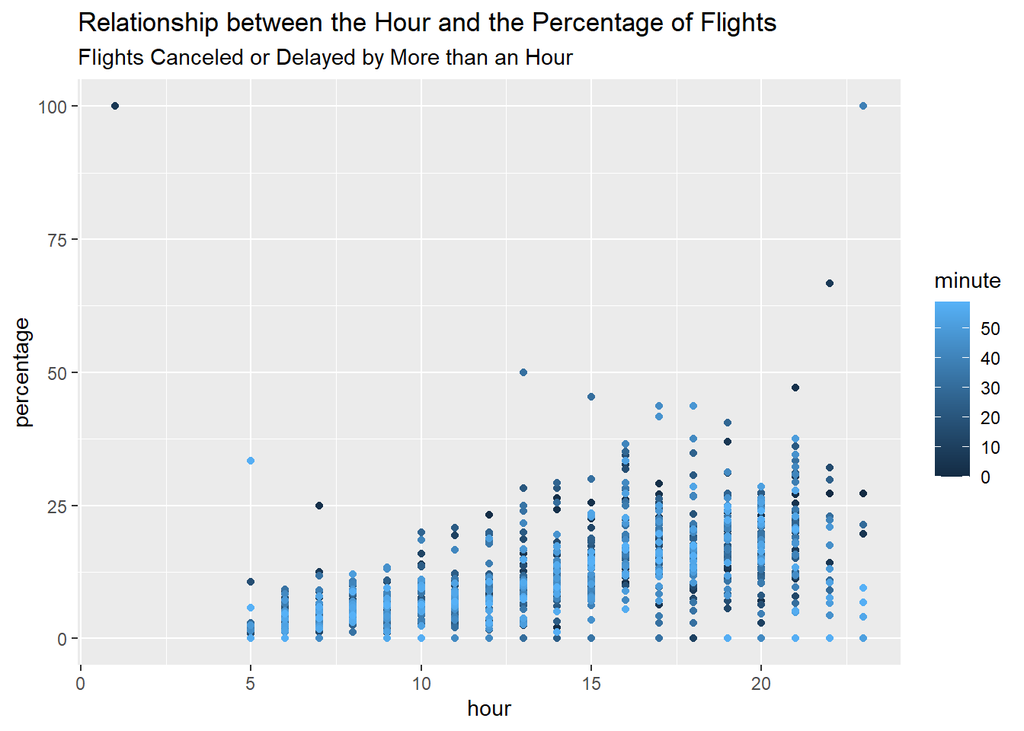

```r
hour_per_can_or_del <- flights %>%
  group_by(hour, minute) %>%
  summarize(
    total_flights = n(),
    can_or_del = sum(is.na(dep_delay) | dep_delay > 60),
    percentage = (can_or_del / total_flights) * 100
  )

hour_per_can_or_del %>%
  ggplot() +
  geom_point(mapping = aes(x = hour, y = percentage, color = minute)) +
  labs(title = "Relationship between the Hour and the Percentage of Flights", subtitle = "Flights Canceled or Delayed by More than an Hour")
```

- Since every minute in an hour has a different percentage, I fed both `hour` and `minute` into `group_by`. Otherwise, the plot would not be accurate. I also added a `color` aesthetic by minute to represent percentages more appropriately. On the other hand, if you’re looking for outliers, yes, there are clearly some. Finally, this analysis can help answer the question “When is the riskiest time of day to fly?” Well, you might answer this by saying it’s generally between 12:00 and 00:00. For example, 16 p.m. and 21 p.m.

### Above, we found dates on which a lot of cancellations and long delays occurred. However, several flights were able to leave on time or early on those dates. So I created a data set that contains the flights that left on time or early on those dates.

```r
left_on_time_or_early <- flights %>%
  filter(year == 2013) %>%
  group_by(month, day) %>%
  summarize(
    total_flights = n(),
    canceled_or_delayed = sum(is.na(dep_delay) | dep_delay > 60),
    exceed_35 = (canceled_or_delayed / total_flights) * 100,
    on_time_or_early = sum(dep_delay <= 0 & !is.na(dep_delay)),
  ) %>%
  filter(exceed_35 > 35)

left_on_time_or_early
```

```
## # A tibble: 12 × 6
## # Groups:   month [7]
##    month   day total_flights canceled_or_delayed exceed_35 on_time_or_early
##    <int> <int>         <int>               <int>     <dbl>            <int>
##  1     2     8           930                 506      54.4              219
##  2     2     9           684                 419      61.3              125
##  3     3     8           979                 574      58.6              146
##  4     5    23           988                 435      44.0              329
##  5     6    24           994                 348      35.0              369
##  6     6    28           994                 369      37.1              309
##  7     7     1           966                 407      42.1              229
##  8     7    10          1004                 364      36.3              360
##  9     7    23           997                 362      36.3              257
## 10     9     2           929                 326      35.1              386
## 11     9    12           992                 404      40.7              386
## 12    12     5           969                 385      39.7              326
```

### For each date in the data set from the previous problem, I found the average scheduled hour of departure.

```r
left_on_time_or_early <- flights %>%
  group_by(month, day) %>%
  summarize(
    total_flights = n(),
    on_time_or_early = sum(dep_delay <= 0 & !is.na(dep_delay)),
    canceled_or_delayed = sum(is.na(dep_delay) | dep_delay > 60),
    exceed_35 = (canceled_or_delayed / total_flights) * 100,
    avg_scheduled_hour_of_dep = mean(sched_dep_time %/% 100)
  ) %>%
  filter(exceed_35 > 35)

left_on_time_or_early
```

```
## # A tibble: 12 × 7
## # Groups:   month [7]
##    month   day total_flights on_time_or_early canceled_or_delayed exceed_35
##    <int> <int>         <int>            <int>               <int>     <dbl>
##  1     2     8           930              219                 506      54.4
##  2     2     9           684              125                 419      61.3
##  3     3     8           979              146                 574      58.6
##  4     5    23           988              329                 435      44.0
##  5     6    24           994              369                 348      35.0
##  6     6    28           994              309                 369      37.1
##  7     7     1           966              229                 407      42.1
##  8     7    10          1004              360                 364      36.3
##  9     7    23           997              257                 362      36.3
## 10     9     2           929              386                 326      35.1
## 11     9    12           992              386                 404      40.7
## 12    12     5           969              326                 385      39.7
## # ℹ 1 more variable: avg_scheduled_hour_of_dep <dbl>
```

- Average scheduled hour of departure values show that the flights’ hour is around 13 p.m.

### Conclusion

- We found that there were 12 days when the percentage of canceled or late departures exceeded 35 percent. The main reason for this is the extreme weather conditions in and around NYC, which we found through a Google search. Based on the graph we created, we obtained the percentages of canceled or late departures by hours. The percentages at 16 and 21 hours are quite high. Then, we also saw the number of flights that departed on time or earlier in these 12 days. Finally, we found that the scheduled departure time for this range of days was 13 o’clock, so we can guess that the on-time and earlier flights were in the early morning hours.